# Nation_Level_Analysis

Andrew Deighan

April 11, 2017

### Importing, Cleaning, and Summarizing Data

Import 2015 BRFSS and select only variables of interest and export as CSV files for future use.

```r
#library(Hmisc)
#BRFSS2015full <- sasxport.get("LLCP2015.XPT")
#BRFSS2014full <- sasxport.get("LLCP2014.XPT")
#BRFSS2013full <- sasxport.get("LLCP2013.XPT")
#BRFSS2012full <- sasxport.get("LLCP2012.XPT")
#BRFSS2011full <- sasxport.get("LLCP2011.XPT")

#t15.data <- BRFSS2015full[,c("hlthpln1", "persdoc2", "checkup1", "x.llcpwt", "x.state")]
#t14.data <- BRFSS2014full[,c("hlthpln1", "persdoc2", "checkup1", "x.llcpwt", "x.state")]
#t13.data <- BRFSS2013full[,c("hlthpln1", "persdoc2", "checkup1", "x.llcpwt", "x.state")]
#t12.data <- BRFSS2012full[,c("hlthpln1", "persdoc2", "checkup1", "x.llcpwt", "x.state")]
#t11.data <- BRFSS2011full[,c("hlthpln1", "persdoc2", "checkup1", "x.llcpwt", "x.state")]

#write.csv(t15.data, '2015 BRFSS Data.csv')
#write.csv(t14.data, '2014 BRFSS Data.csv')
#write.csv(t13.data, '2013 BRFSS Data.csv')
#write.csv(t12.data, '2012 BRFSS Data.csv')
#write.csv(t11.data, '2011 BRFSS Data.csv')

#rm(BRFSS2011full, BRFSS2012full, BRFSS2013full, BRFSS2014full, BRFSS2015full)
```

```r
### this is dummy code to aid in knitting

t15.data <- data.frame(read.csv("2015 BRFSS Data.csv")[,2:6])
t14.data <- data.frame(read.csv("2014 BRFSS Data.csv")[,2:6])
t13.data <- data.frame(read.csv("2013 BRFSS Data.csv")[,2:6])
t12.data <- data.frame(read.csv("2012 BRFSS Data.csv")[,2:6])
t11.data <- data.frame(read.csv("2011 BRFSS Data.csv")[,2:6])
```

Clean data sets of missing values:

- For hlthpln1
  - 1: yes insurance
  - 2: no insurance
  - 7: unsure
  - 9: refused to answer
- For persdoc2
  - 1: yes one personal doctor
  - 2: yes more than one
  - 3: no personal doctor
  - 7: unsure
  - 9: refused to answer
- For checkup1
  - 1: checkup within past year
  - 2: checkup within two years
  - 3: checkup within five years
  - 4: more than five years since checkup
  - 7: unsure
  - 8: never had checkup
  - 9: refused to answer

```r
cleaner <- function(x){
      df <- x
      for(i in 1:5){
            df <- df[!is.na(df[,i]),]
      }

      for(i in 1:3){
           df <- df[df[,i] != 7 & df[,i] != 9,]
      }


      df
}

t11.data <- cleaner(t11.data)
t12.data <- cleaner(t12.data)
t13.data <- cleaner(t13.data)
t14.data <- cleaner(t14.data)
t15.data <- cleaner(t15.data)

# Since we are only interested in whether or not respondents have a personal doctor we will treat those who reported having multiple doctors and those who reported only having one doctor the same. Now individuals with personal doctors will be coded as '1' and those without as '3'.

persdocmod <- function(x){
      df <- x
      df[df[,2] == 2,2] <- 1

      df
}

t11.data <- persdocmod(t11.data)
t12.data <- persdocmod(t12.data)
t13.data <- persdocmod(t13.data)
t14.data <- persdocmod(t14.data)
t15.data <- persdocmod(t15.data)

allyears <- rbind(t11.data, t12.data, t13.data, t14.data, t15.data)
```

Below we create summary tables of the data for each year and for all years combined. For each data set I made three 2 by *c* summary tables:

1. Insurance status by possession of a personal doctor
2. Insurance status by doctor utilization
3. Insruance status by doctor utilization given possesion of a personal doctor

```r
library(dplyr)
persdoc.table <- function(x){

      tab <- x %>% group_by(hlthpln1, persdoc2) %>% summarize(wt_sum = sum(x.llcpwt)) %>%
      tidyr::spread(key = persdoc2, value = wt_sum) %>% ungroup()

      tab
}

ST_PD_t11 <- persdoc.table(t11.data)
ST_PD_t12 <- persdoc.table(t12.data)
ST_PD_t13 <- persdoc.table(t13.data)
ST_PD_t14 <- persdoc.table(t14.data)
ST_PD_t15 <- persdoc.table(t15.data)
ST_PD_ay <- persdoc.table(allyears)

checkup.table <- function(x){

      tab <- x %>% group_by(hlthpln1, checkup1) %>% summarize(wt_sum = sum(x.llcpwt)) %>%
      tidyr::spread(key = checkup1, value = wt_sum) %>% ungroup()

      tab
}

ST_CU_t11 <- checkup.table(t11.data)
ST_CU_t12 <- checkup.table(t12.data)
ST_CU_t13 <- checkup.table(t13.data)
ST_CU_t14 <- checkup.table(t14.data)
ST_CU_t15 <- checkup.table(t15.data)
ST_CU_ay <- checkup.table(allyears)

ST_CUgPD_t11 <- checkup.table(t11.data[t11.data$persdoc2 == 1,])
ST_CUgPD_t12 <- checkup.table(t12.data[t12.data$persdoc2 == 1,])
ST_CUgPD_t13 <- checkup.table(t13.data[t13.data$persdoc2 == 1,])
ST_CUgPD_t14 <- checkup.table(t14.data[t14.data$persdoc2 == 1,])
ST_CUgPD_t15 <- checkup.table(t15.data[t15.data$persdoc2 == 1,])
ST_CUgPD_ay <- checkup.table(allyears[allyears$persdoc2 == 1,])
```

### Proportional Frequency Bar Charts

Next we will display some frequency bar charts to get a visual in the proportional differences between the insured and uninsured. First let us look at possession of a personal doctor.

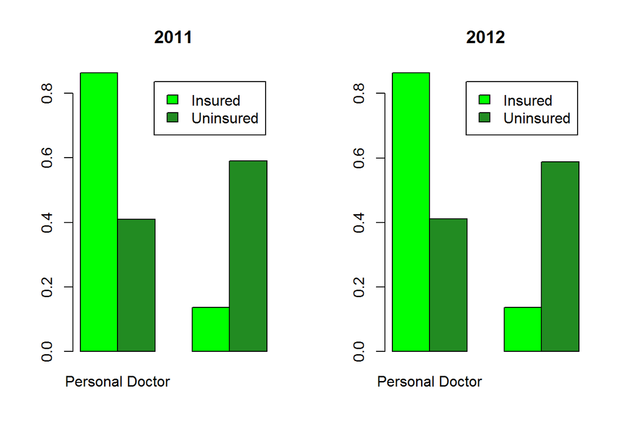

```r
PD.props <- function(x){
      vec <- rep(0,4)
      c <- 0
      for(i in 1:2){
            for(j in 2:3){
                  c <- c + 1
                  vec[c] <- as.numeric(x[i,j]/sum(x[i,2:3]))
            }
      }
      matrix(vec, nrow = 2, ncol = 2, byrow = TRUE)
}


PD11 <- PD.props(ST_PD_t11)
PD12 <- PD.props(ST_PD_t12)
PD13 <- PD.props(ST_PD_t13)
PD14 <- PD.props(ST_PD_t14)
PD15 <- PD.props(ST_PD_t15)
PDay <- PD.props(ST_PD_ay)

par(mfrow=c(1,2))

barplot(PD11, beside = TRUE, names.arg = c('Personal Doctor', 'No Personal Doctor'), legend.text = c('Insured', 'Uninsured'), main = c('2011'), col = c('green', 'forestgreen'))
barplot(PD12, beside = TRUE, names.arg = c('Personal Doctor', 'No Personal Doctor'), legend.text = c('Insured', 'Uninsured'), main = c('2012'), col = c('green', 'forestgreen'))
```

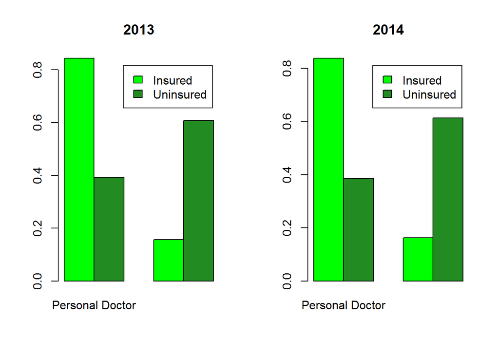

```r
barplot(PD13, beside = TRUE, names.arg = c('Personal Doctor', 'No Personal Doctor'), legend.text = c('Insured', 'Uninsured'), main = c('2013'), col = c('green', 'forestgreen'))
barplot(PD14, beside = TRUE, names.arg = c('Personal Doctor', 'No Personal Doctor'), legend.text = c('Insured', 'Uninsured'), main = c('2014'), col = c('green', 'forestgreen'))
```

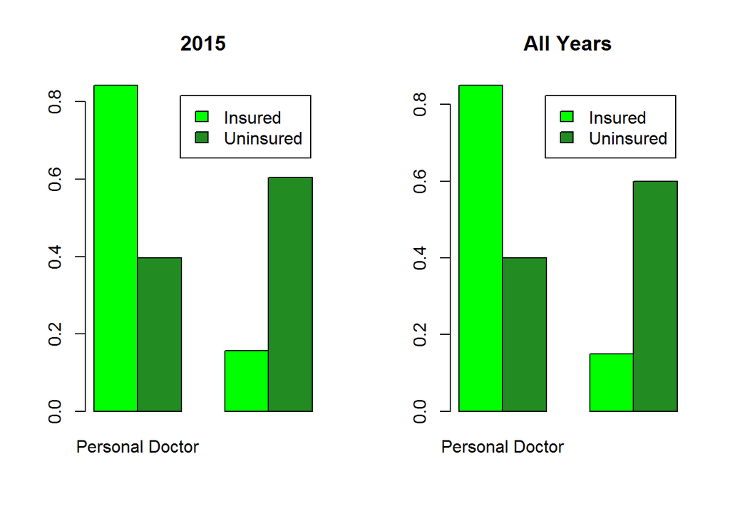

```r
barplot(PD15, beside = TRUE, names.arg = c('Personal Doctor', 'No Personal Doctor'), legend.text = c('Insured', 'Uninsured'), main = c('2015'), col = c('green', 'forestgreen'))
barplot(PDay, beside = TRUE, names.arg = c('Personal Doctor', 'No Personal Doctor'), legend.text = c('Insured', 'Uninsured'), main = c('All Years'), col = c('green', 'forestgreen'))
```

Next lets look at doctor utilization and doctor utilization given that the individual has a personal doctor

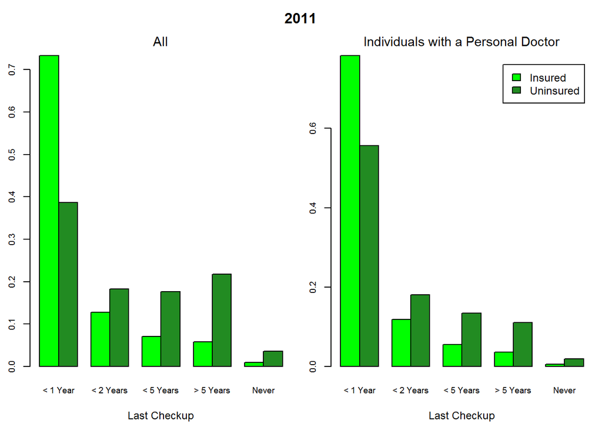

```r
CU.props <- function(x){

      vec <- rep(0,10)
      c <- 0

      for(i in 1:2){
            for(j in 2:6){
                  c <- c+1
                  vec[c] <- as.numeric(x[i,j]/sum(x[i,2:6]))
            }
      }

      matrix(vec, nrow = 2, ncol = 5, byrow = TRUE)
}

CUgPD.props <- function(x){

      vec <- rep(0,10)
      c <- 0

      for(i in 1:2){
            for(j in 2:6){
                  c <- c+1
                  vec[c] <- as.numeric(x[i,j]/sum(x[i,2:6]))
            }
      }

      matrix(vec, nrow = 2, ncol = 5, byrow = TRUE)
}

CUgPD11 <- CUgPD.props(ST_CUgPD_t11)
CUgPD12 <- CUgPD.props(ST_CUgPD_t12)
CUgPD13 <- CUgPD.props(ST_CUgPD_t13)
CUgPD14 <- CUgPD.props(ST_CUgPD_t14)
CUgPD15 <- CUgPD.props(ST_CUgPD_t15)
CUgPDay <- CUgPD.props(ST_CUgPD_ay)

CU11 <- CU.props(ST_CU_t11)
CU12 <- CU.props(ST_CU_t12)
CU13 <- CU.props(ST_CU_t13)
CU14 <- CU.props(ST_CU_t14)
CU15 <- CU.props(ST_CU_t15)
CUay <- CU.props(ST_CU_ay)

par(mfrow=c(1,2), mai = c(.7,.35,.35,.1), cex = c(.75), oma = c(0,0,2,0), font.main = 1, cex.axis = .8)

barplot(CU11, beside = TRUE, names.arg = c('< 1 Year', '< 2 Years', '< 5 Years', '> 5 Years', 'Never'), xlab = 'Last Checkup', main = c('All'), col = c('green', 'forestgreen'), space = c(0,.7))
barplot(CUgPD11, beside = TRUE, names.arg = c('< 1 Year', '< 2 Years', '< 5 Years', '> 5 Years', 'Never'), xlab = 'Last Checkup', legend.text = c('Insured', 'Uninsured'), main = c('Individuals with a Personal Doctor'), col = c('green', 'forestgreen'), space = c(0,.7))
mtext('2011', outer = TRUE, font = 2)
```

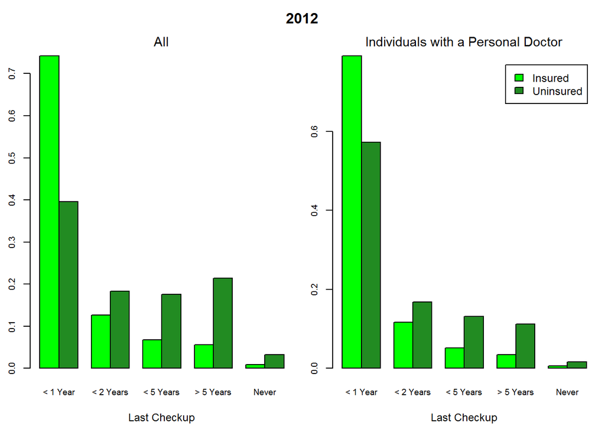

```r
barplot(CU12, beside = TRUE, names.arg = c('< 1 Year', '< 2 Years', '< 5 Years', '> 5 Years', 'Never'), xlab = 'Last Checkup', main = c('All'), col = c('green', 'forestgreen'), space = c(0,.7))
barplot(CUgPD12, beside = TRUE, names.arg = c('< 1 Year', '< 2 Years', '< 5 Years', '> 5 Years', 'Never'), xlab = 'Last Checkup', legend.text = c('Insured', 'Uninsured'), main = c('Individuals with a Personal Doctor'), col = c('green', 'forestgreen'), space = c(0,.7))
mtext('2012', outer = TRUE, font = 2)
```

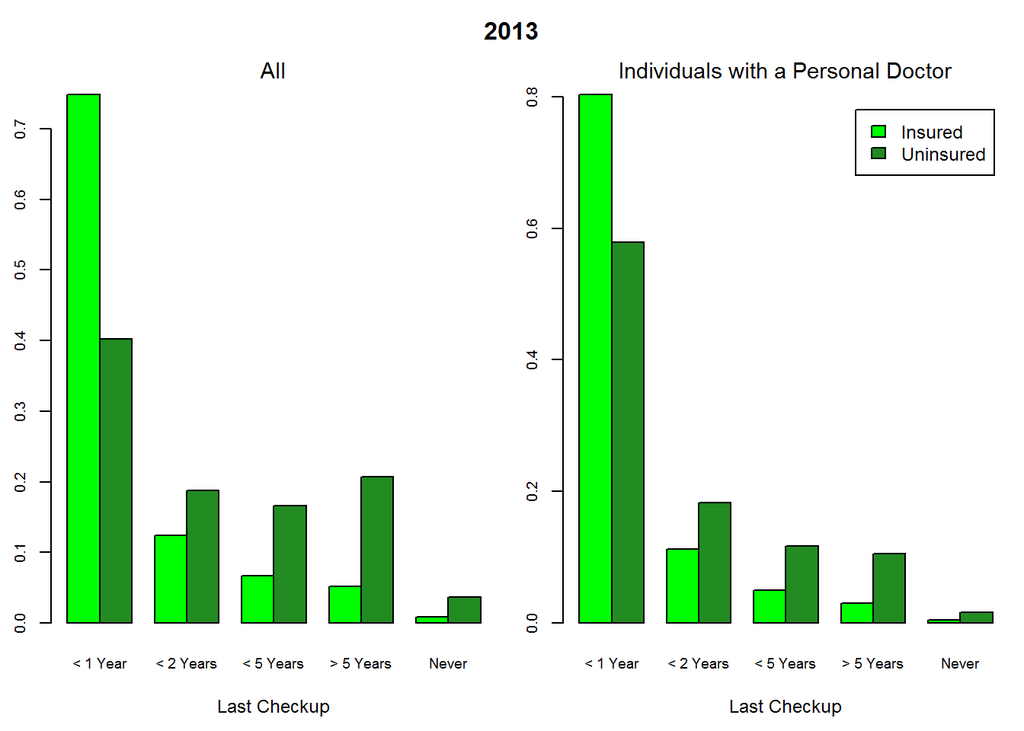

```r
barplot(CU13, beside = TRUE, names.arg = c('< 1 Year', '< 2 Years', '< 5 Years', '> 5 Years', 'Never'), xlab = 'Last Checkup', main = c('All'), col = c('green', 'forestgreen'), space = c(0,.7))
barplot(CUgPD13, beside = TRUE, names.arg = c('< 1 Year', '< 2 Years', '< 5 Years', '> 5 Years', 'Never'), xlab = 'Last Checkup', legend.text = c('Insured', 'Uninsured'), main = c('Individuals with a Personal Doctor'), col = c('green', 'forestgreen'), space = c(0,.7))
mtext('2013', outer = TRUE, font = 2)
```

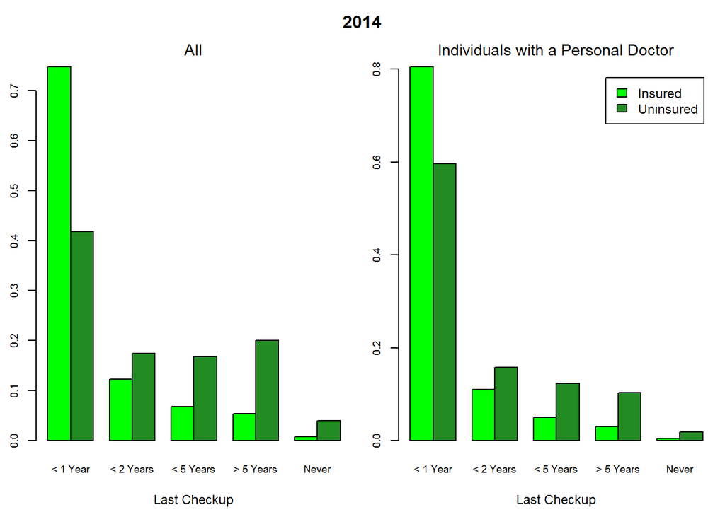

```r
barplot(CU14, beside = TRUE, names.arg = c('< 1 Year', '< 2 Years', '< 5 Years', '> 5 Years', 'Never'), xlab = 'Last Checkup', main = c('All'), col = c('green', 'forestgreen'), space = c(0,.7))
barplot(CUgPD14, beside = TRUE, names.arg = c('< 1 Year', '< 2 Years', '< 5 Years', '> 5 Years', 'Never'), xlab = 'Last Checkup', legend.text = c('Insured', 'Uninsured'), main = c('Individuals with a Personal Doctor'), col = c('green', 'forestgreen'), space = c(0,.7))
mtext('2014', outer = TRUE, font = 2)
```

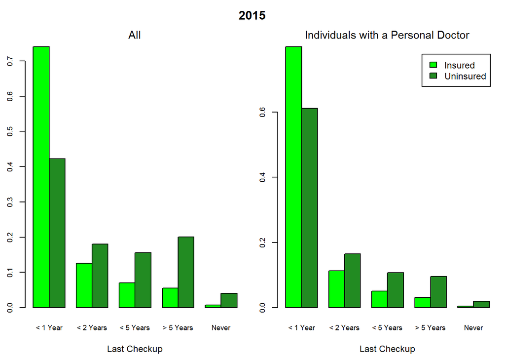

```r
barplot(CU15, beside = TRUE, names.arg = c('< 1 Year', '< 2 Years', '< 5 Years', '> 5 Years', 'Never'), xlab = 'Last Checkup', main = c('All'), col = c('green', 'forestgreen'), space = c(0,.7))
barplot(CUgPD15, beside = TRUE, names.arg = c('< 1 Year', '< 2 Years', '< 5 Years', '> 5 Years', 'Never'), xlab = 'Last Checkup', legend.text = c('Insured', 'Uninsured'), main = c('Individuals with a Personal Doctor'), col = c('green', 'forestgreen'), space = c(0,.7))
mtext('2015', outer = TRUE, font = 2)
```

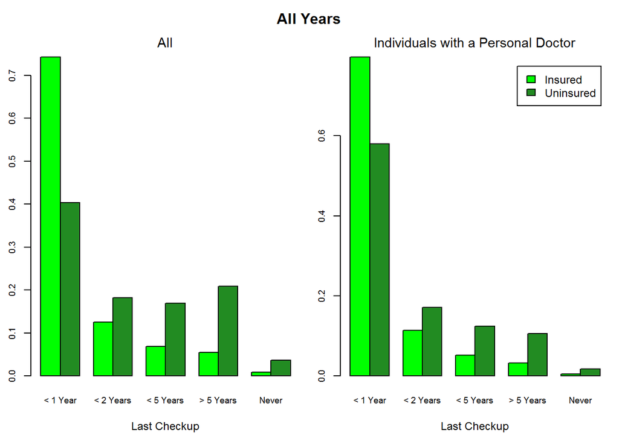

```r
barplot(CUay, beside = TRUE, names.arg = c('< 1 Year', '< 2 Years', '< 5 Years', '> 5 Years', 'Never'), xlab = 'Last Checkup', main = c('All'), col = c('green', 'forestgreen'), space = c(0,.7))
barplot(CUgPDay, beside = TRUE, names.arg = c('< 1 Year', '< 2 Years', '< 5 Years', '> 5 Years', 'Never'), xlab = 'Last Checkup', legend.text = c('Insured', 'Uninsured'), main = c('Individuals with a Personal Doctor'), col = c('green', 'forestgreen'), space = c(0,.7))
mtext('All Years', outer = TRUE, font = 2)
```

### Pearson Chi-Square Tests for General Association

Now that we have had a graphical look at the difference in proportions for our variables of interest between the insured and uninsured. Let’s do Pearson Chi-Square tests for each variable to see if there is general association with insurance status. First we look at the association between insurance status and personal doctor status.

```r
ST_PD_t11 %>% select(-hlthpln1) %>% chisq.test()
```

```
##
##  Pearson's Chi-squared test with Yates' continuity correction
##
## data:  .
## X-squared = 41897000, df = 1, p-value < 2.2e-16
```

```r
ST_PD_t12 %>% select(-hlthpln1) %>% chisq.test()
```

```
##
##  Pearson's Chi-squared test with Yates' continuity correction
##
## data:  .
## X-squared = 42654000, df = 1, p-value < 2.2e-16
```

```r
ST_PD_t13 %>% select(-hlthpln1) %>% chisq.test()
```

```
##
##  Pearson's Chi-squared test with Yates' continuity correction
##
## data:  .
## X-squared = 39042000, df = 1, p-value < 2.2e-16
```

```r
ST_PD_t14 %>% select(-hlthpln1) %>% chisq.test()
```

```
##
##  Pearson's Chi-squared test with Yates' continuity correction
##
## data:  .
## X-squared = 33774000, df = 1, p-value < 2.2e-16
```

```r
ST_PD_t15 %>% select(-hlthpln1) %>% chisq.test()
```

```
##
##  Pearson's Chi-squared test with Yates' continuity correction
##
## data:  .
## X-squared = 31142000, df = 1, p-value < 2.2e-16
```

```r
ST_PD_ay %>% select(-hlthpln1) %>% chisq.test()
```

```
##
##  Pearson's Chi-squared test with Yates' continuity correction
##
## data:  .
## X-squared = 188170000, df = 1, p-value < 2.2e-16
```

The extremely large chi-square test-statistics and correspondingly low p-values for each year and for all years combined indicate that there is a strong association between insurance status and whether or not a person has a personal doctor.

Next we will look at the association between insurance status and doctor utilization (time since last checkup).

```r
ST_CU_t11 %>% select(-hlthpln1) %>% chisq.test()
```

```
##
##  Pearson's Chi-squared test
##
## data:  .
## X-squared = 23050000, df = 4, p-value < 2.2e-16
```

```r
ST_CU_t12 %>% select(-hlthpln1) %>% chisq.test()
```

```
##
##  Pearson's Chi-squared test
##
## data:  .
## X-squared = 23870000, df = 4, p-value < 2.2e-16
```

```r
ST_CU_t13 %>% select(-hlthpln1) %>% chisq.test()
```

```
##
##  Pearson's Chi-squared test
##
## data:  .
## X-squared = 23423000, df = 4, p-value < 2.2e-16
```

```r
ST_CU_t14 %>% select(-hlthpln1) %>% chisq.test()
```

```
##
##  Pearson's Chi-squared test
##
## data:  .
## X-squared = 19344000, df = 4, p-value < 2.2e-16
```

```r
ST_CU_t15 %>% select(-hlthpln1) %>% chisq.test()
```

```
##
##  Pearson's Chi-squared test
##
## data:  .
## X-squared = 16670000, df = 4, p-value < 2.2e-16
```

```r
ST_CU_ay %>% select(-hlthpln1) %>% chisq.test()
```

```
##
##  Pearson's Chi-squared test
##
## data:  .
## X-squared = 107210000, df = 4, p-value < 2.2e-16
```

Again, the large test-statistics and correspondingly low p-values for each year and for all years combined indicate that there is a strong association between insurance status and doctor utilization.

Now we will look at the association between insurance status and doctor utilization given that the person has a personal doctor.

```r
ST_CUgPD_t11 %>% select(-hlthpln1) %>% chisq.test()
```

```
##
##  Pearson's Chi-squared test
##
## data:  .
## X-squared = 5372700, df = 4, p-value < 2.2e-16
```

```r
ST_CUgPD_t12 %>% select(-hlthpln1) %>% chisq.test()
```

```
##
##  Pearson's Chi-squared test
##
## data:  .
## X-squared = 5663600, df = 4, p-value < 2.2e-16
```

```r
ST_CUgPD_t13 %>% select(-hlthpln1) %>% chisq.test()
```

```
##
##  Pearson's Chi-squared test
##
## data:  .
## X-squared = 5342900, df = 4, p-value < 2.2e-16
```

```r
ST_CUgPD_t14 %>% select(-hlthpln1) %>% chisq.test()
```

```
##
##  Pearson's Chi-squared test
##
## data:  .
## X-squared = 4336800, df = 4, p-value < 2.2e-16
```

```r
ST_CUgPD_t15 %>% select(-hlthpln1) %>% chisq.test()
```

```
##
##  Pearson's Chi-squared test
##
## data:  .
## X-squared = 3195400, df = 4, p-value < 2.2e-16
```

```r
ST_CUgPD_ay %>% select(-hlthpln1) %>% chisq.test()
```

```
##
##  Pearson's Chi-squared test
##
## data:  .
## X-squared = 24199000, df = 4, p-value < 2.2e-16
```

As with the other two variables, the large test-statistics and low p-values for each year and all years combined indicate that there is a strong association between insurance status and doctor utilization gven that a person has a personal doctor.

### Confidence Intervals for Proportional Differences

Now that we know there is general association between all our variables of interest and insurance status, we want to estimate the 95% confidence intervals for the difference in proportions between insured individuals and uninsured individuals at each level of our variables. So, for presence of personal doctor, we want to estimate the difference between the proportion of insured individuals that have a personal doctor and uninsured individuals that have a personal doctor. For doctor utilization we went to estimate the difference between the proportion of insured individuals that have had a checkup within a year and uninsured individuals that have had a checkup within a year, insured individuals that have had a checkup within two years and uninsured individuals that have had a checkup within two years, etc.

First let’s take a look at the difference in proportions for presence of personal doctor.

```r
PD.propdif <- function(x, alpha){

  df <- x

  z <- qnorm(alpha/2, lower.tail = F)
  n1 <- as.numeric( sum(df[1,2:3]) )
  n2 <- as.numeric( sum(df[2,2:3]) )

  p1 <- as.numeric( df[1,2]/sum(df[1,2:3]) )
  p2 <- as.numeric( df[2,2]/sum(df[2,2:3]) )
  dif <- p1 - p2

  LB <- dif - z*sqrt( (p1*(1-p1))/n1 + (p2*(1-p2))/n2 )
  UB <- dif + z*sqrt( (p1*(1-p1))/n1 + (p2*(1-p2))/n2 )

  vec <- c(LB, dif, UB)
  vec
}

PD.pd <- c()
PD.pd <- c(PD.pd, PD.propdif(ST_PD_t11, 0.05))
PD.pd <- c(PD.pd, PD.propdif(ST_PD_t12, 0.05))
PD.pd <- c(PD.pd, PD.propdif(ST_PD_t13, 0.05))
PD.pd <- c(PD.pd, PD.propdif(ST_PD_t14, 0.05))
PD.pd <- c(PD.pd, PD.propdif(ST_PD_t15, 0.05))
PD.pd <- c(PD.pd, PD.propdif(ST_PD_ay, 0.05))

Persdoc.pdif.95CI <- matrix(PD.pd, nrow = 6, ncol = 3, byrow = TRUE,
                            dimnames = list(c("2011", "2012", "2013", "2014", "2015", "All"),
                                            c("Lower.Bound", "Point.Estimate", "Upper.Bound")))

Persdoc.pdif.95CI
```

```
##      Lower.Bound Point.Estimate Upper.Bound
## 2011   0.4547381      0.4548942   0.4550502
## 2012   0.4523966      0.4525505   0.4527045
## 2013   0.4514079      0.4515648   0.4517217
## 2014   0.4511558      0.4513280   0.4515003
## 2015   0.4460847      0.4462675   0.4464502
## All    0.4499567      0.4500297   0.4501027
```

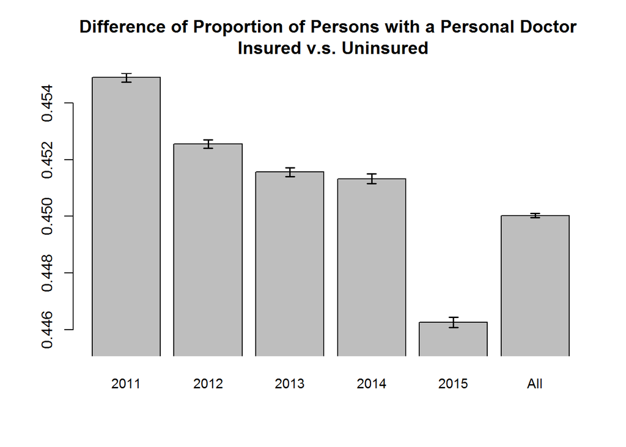

```r
barcenters <- barplot(Persdoc.pdif.95CI[,2], ylim = c( min(Persdoc.pdif.95CI[,1]) - 0.001  , max(Persdoc.pdif.95CI[,3]) ),
                      main = "Difference of Proportion of Persons with a Personal Doctor \n Insured v.s. Uninsured",
                      xpd = FALSE, cex.names = .9 )

segments(barcenters, Persdoc.pdif.95CI[,1], barcenters, Persdoc.pdif.95CI[,3], lwd = 1.5)
arrows(barcenters, Persdoc.pdif.95CI[,1], barcenters, Persdoc.pdif.95CI[,3], lwd = 1.5, angle = 90, code = 3, length = 0.05)
```

Now let’s take a look at doctor utilization

```r
CU.propdif <- function(x, alpha){
  df <- x

  z <- qnorm(alpha/2, lower.tail = F)
  n1 <- as.numeric( sum(df[1,2:6]) )
  n2 <- as.numeric( sum(df[2,2:6]) )

  pe <- c()
  LB <- c()
  UB <- c()

  for(i in 2:6){

    p1 <- as.numeric( df[1,i]/sum(df[1,2:6]) )
    p2 <- as.numeric( df[2,i]/sum(df[2,2:6]) )
    dif <- p1 - p2

    pe <- c(pe, dif)
    LB <- c(LB, dif - z*sqrt( (p1*(1-p1))/n1 + (p2*(1-p2))/n2 ) )
    UB <- c(UB, dif + z*sqrt( (p1*(1-p1))/n1 + (p2*(1-p2))/n2 ) )

  }

  p1 <- as.numeric( sum(df[1,4:6])/sum(df[1,2:6]) )
  p2 <- as.numeric( sum(df[2,4:6])/sum(df[2,2:6]) )
  dif <- p1 - p2

  pe <- c(pe, dif)
  LB <- c(LB, dif - z*sqrt( (p1*(1-p1))/n1 + (p2*(1-p2))/n2 ) )
  UB <- c(UB, dif + z*sqrt( (p1*(1-p1))/n1 + (p2*(1-p2))/n2 ) )


  out <- matrix(data = c(UB, pe, LB), nrow = 3, ncol = 6, byrow = TRUE,
                dimnames = list(c("Upper Bound", "Point Estimate", "Lower Bound"),
                                c("< 1 Year", "< 2 Years", "< 5 Years",
                                  "> 5 Years", "Never", "All > 2 Years")))
  out
}

CU.pdif.t11 <- CU.propdif(ST_CU_t11, 0.05)
CU.pdif.t12 <- CU.propdif(ST_CU_t12, 0.05)
CU.pdif.t13 <- CU.propdif(ST_CU_t13, 0.05)
CU.pdif.t14 <- CU.propdif(ST_CU_t14, 0.05)
CU.pdif.t15 <- CU.propdif(ST_CU_t15, 0.05)
CU.pdif.ay <- CU.propdif(ST_CU_ay, 0.05)

CU.pdif.t11
```

```
##                 < 1 Year   < 2 Years  < 5 Years  > 5 Years       Never
## Upper Bound    0.3465096 -0.05453529 -0.1047157 -0.1597152 -0.02695020
## Point Estimate 0.3463498 -0.05466124 -0.1048363 -0.1598442 -0.02700812
## Lower Bound    0.3461901 -0.05478719 -0.1049569 -0.1599731 -0.02706604
##                All > 2 Years
## Upper Bound       -0.2915314
## Point Estimate    -0.2916886
## Lower Bound       -0.2918458
```

```r
CU.pdif.t12
```

```
##                 < 1 Year   < 2 Years  < 5 Years  > 5 Years       Never
## Upper Bound    0.3462399 -0.05665546 -0.1078059 -0.1576691 -0.02352948
## Point Estimate 0.3460821 -0.05677944 -0.1079243 -0.1577951 -0.02358331
## Lower Bound    0.3459244 -0.05690341 -0.1080427 -0.1579211 -0.02363714
##                All > 2 Years
## Upper Bound       -0.2891485
## Point Estimate    -0.2893027
## Lower Bound       -0.2894569
```

```r
CU.pdif.t13
```

```
##                 < 1 Year   < 2 Years   < 5 Years  > 5 Years       Never
## Upper Bound    0.3454637 -0.06343073 -0.09883540 -0.1546090 -0.02799619
## Point Estimate 0.3453027 -0.06355806 -0.09895396 -0.1547361 -0.02805455
## Lower Bound    0.3451417 -0.06368539 -0.09907253 -0.1548633 -0.02811290
##                All > 2 Years
## Upper Bound       -0.2815879
## Point Estimate    -0.2817446
## Lower Bound       -0.2819013
```

```r
CU.pdif.t14
```

```
##                 < 1 Year   < 2 Years   < 5 Years  > 5 Years       Never
## Upper Bound    0.3294772 -0.05101145 -0.09966246 -0.1462303 -0.03192293
## Point Estimate 0.3293002 -0.05114743 -0.09979353 -0.1463691 -0.03199012
## Lower Bound    0.3291232 -0.05128342 -0.09992460 -0.1465079 -0.03205732
##                All > 2 Years
## Upper Bound       -0.2779803
## Point Estimate    -0.2781528
## Lower Bound       -0.2783252
```

```r
CU.pdif.t15
```

```
##                 < 1 Year   < 2 Years   < 5 Years  > 5 Years       Never
## Upper Bound    0.3182622 -0.05406428 -0.08523932 -0.1455210 -0.03275056
## Point Estimate 0.3180750 -0.05420961 -0.08537445 -0.1456686 -0.03282237
## Lower Bound    0.3178877 -0.05435494 -0.08550957 -0.1458162 -0.03289418
##                All > 2 Years
## Upper Bound       -0.2636833
## Point Estimate    -0.2638654
## Lower Bound       -0.2640474
```

```r
CU.pdif.ay
```

```
##                 < 1 Year   < 2 Years  < 5 Years  > 5 Years       Never
## Upper Bound    0.3389643 -0.05646293 -0.1002086 -0.1537160 -0.02830135
## Point Estimate 0.3388896 -0.05652144 -0.1002641 -0.1537754 -0.02832857
## Lower Bound    0.3388148 -0.05657995 -0.1003196 -0.1538349 -0.02835580
##                All > 2 Years
## Upper Bound       -0.2822951
## Point Estimate    -0.2823681
## Lower Bound       -0.2824412
```

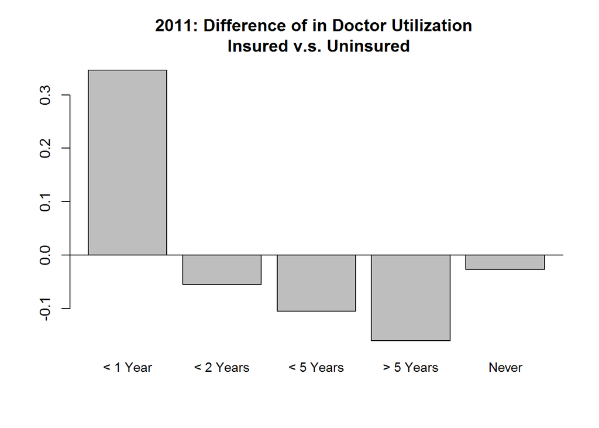

```r
barplot(CU.pdif.t11[2,1:5], ylim = c( min(CU.pdif.t11[3,1:5]) , max(CU.pdif.t11[1,1:5]) ),
        main = "2011: Difference of in Doctor Utilization \n Insured v.s. Uninsured",
        xpd = FALSE, cex.names = .9 )
abline(h = 0)
```

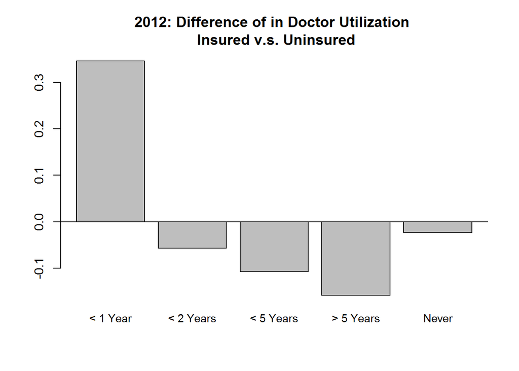

```r
barplot(CU.pdif.t12[2,1:5], ylim = c( min(CU.pdif.t12[3,1:5]) , max(CU.pdif.t12[1,1:5]) ),
        main = "2012: Difference of in Doctor Utilization \n Insured v.s. Uninsured",
        xpd = FALSE, cex.names = .9 )
abline(h = 0)
```

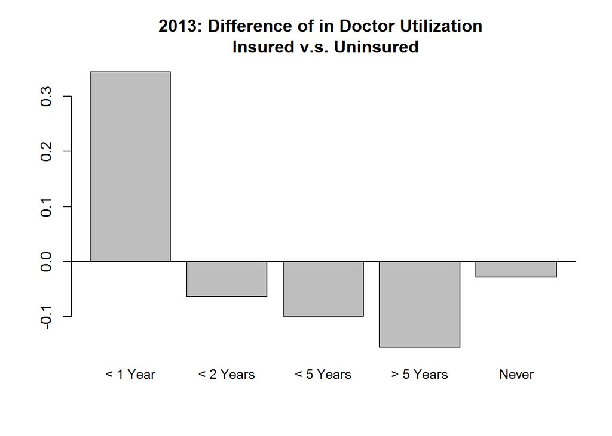

```r
barplot(CU.pdif.t13[2,1:5], ylim = c( min(CU.pdif.t13[3,1:5]) , max(CU.pdif.t13[1,1:5]) ),
        main = "2013: Difference of in Doctor Utilization \n Insured v.s. Uninsured",
        xpd = FALSE, cex.names = .9 )
abline(h = 0)
```

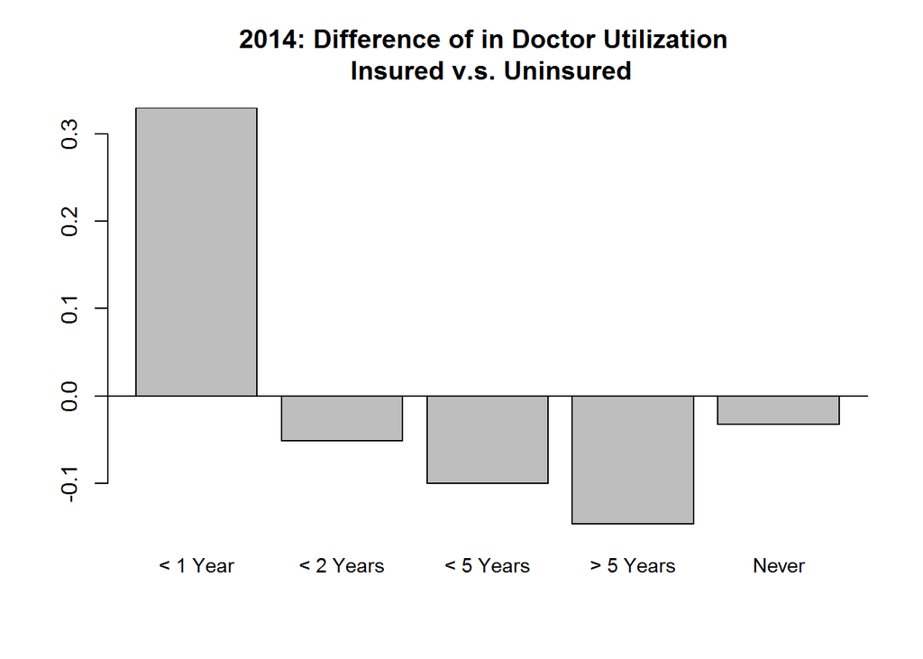

```r
barplot(CU.pdif.t14[2,1:5], ylim = c( min(CU.pdif.t14[3,1:5]) , max(CU.pdif.t14[1,1:5]) ),
        main = "2014: Difference of in Doctor Utilization \n Insured v.s. Uninsured",
        xpd = FALSE, cex.names = .9 )
abline(h = 0)
```

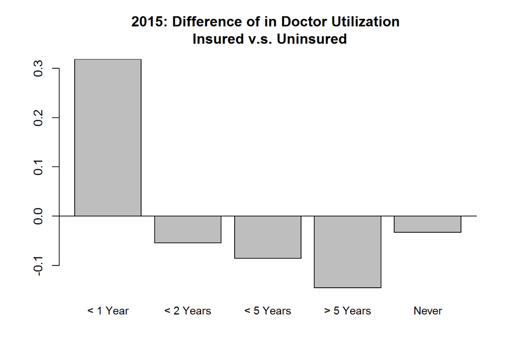

```r
barplot(CU.pdif.t15[2,1:5], ylim = c( min(CU.pdif.t15[3,1:5]) , max(CU.pdif.t15[1,1:5]) ),
        main = "2015: Difference of in Doctor Utilization \n Insured v.s. Uninsured",
        xpd = FALSE, cex.names = .9 )
abline(h = 0)
```

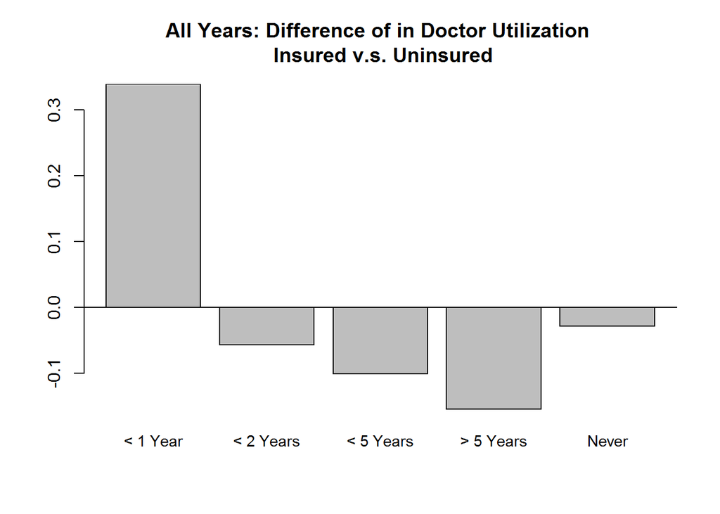

```r
barplot(CU.pdif.ay[2,1:5], ylim = c( min(CU.pdif.ay[3,1:5]) , max(CU.pdif.ay[1,1:5]) ),
        main = "All Years: Difference of in Doctor Utilization \n Insured v.s. Uninsured",
        xpd = FALSE, cex.names = .9 )
abline(h = 0)
```

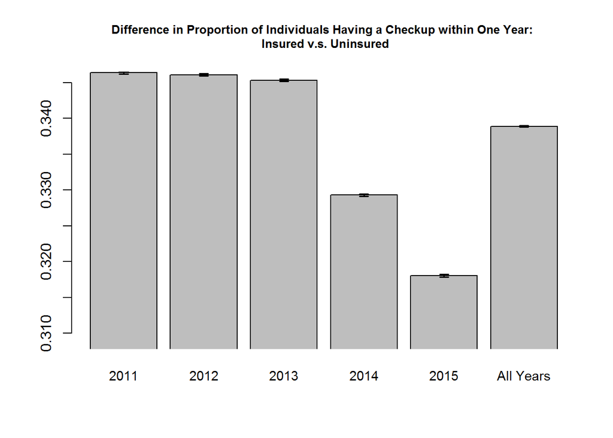

```r
CU.extremes.dif <- matrix(data = c(CU.pdif.t11[3:1,c(1, 6)], CU.pdif.t12[3:1,c(1, 6)], CU.pdif.t13[3:1,c(1, 6)],
                                   CU.pdif.t14[3:1,c(1, 6)], CU.pdif.t15[3:1,c(1, 6)], CU.pdif.ay[3:1,c(1, 6)]),
                          nrow = 6, ncol = 6, byrow = TRUE,
                          dimnames = list(c("2011", "2012", "2013", "2014", "2015", "All Years"),
                                          c("Lower Bound < 1", "Point Estimate < 1", "Upper Bound < 1",
                                            "Lower Bound > 5", "Point Estimate > 5", "Upper Bound > 5")))

barcenters <- barplot(CU.extremes.dif[,2], ylim = c( min(CU.extremes.dif[,1]) - 0.01 , max(CU.extremes.dif[,3]) ),
        main = "Difference in Proportion of Individuals Having a Checkup within One Year: \n Insured v.s. Uninsured",
        xpd = FALSE, cex.names = .9, cex.main = .8 )
segments(barcenters, CU.extremes.dif[,1], barcenters, CU.extremes.dif[,3], lwd = 1.5)
arrows(barcenters, CU.extremes.dif[,1], barcenters, CU.extremes.dif[,3], lwd = 1.5, angle = 90, code = 3, length = 0.05)
```

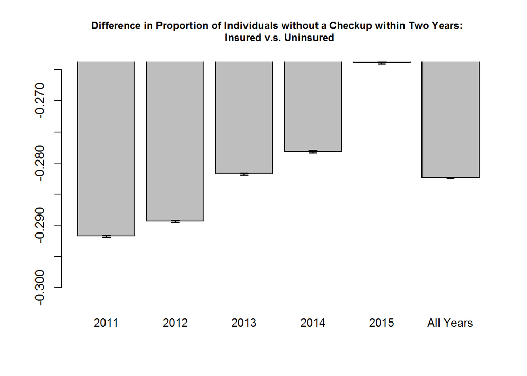

```r
barcenters <- barplot(CU.extremes.dif[,5], ylim = c( min(CU.extremes.dif[,4]) - 0.01 , max(CU.extremes.dif[,6]) ),
        main = "Difference in Proportion of Individuals without a Checkup within Two Years: \n Insured v.s. Uninsured",
        xpd = FALSE, cex.names = .9, cex.main = .8 )
segments(barcenters, CU.extremes.dif[,4], barcenters, CU.extremes.dif[,6], lwd = 1.5)
arrows(barcenters, CU.extremes.dif[,4], barcenters, CU.extremes.dif[,6], lwd = 1.5, angle = 90, code = 3, length = 0.05)
```

Now we’ll look at doctor utilization for those individuals that have a personal doctor

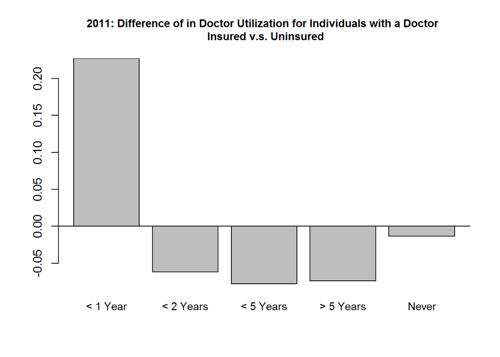

```r
CUgD.pdif.t11 <- CU.propdif(ST_CUgPD_t11, 0.05)
CUgD.pdif.t12 <- CU.propdif(ST_CUgPD_t12, 0.05)
CUgD.pdif.t13 <- CU.propdif(ST_CUgPD_t13, 0.05)
CUgD.pdif.t14 <- CU.propdif(ST_CUgPD_t14, 0.05)
CUgD.pdif.t15 <- CU.propdif(ST_CUgPD_t15, 0.05)
CUgD.pdif.ay <- CU.propdif(ST_CUgPD_ay, 0.05)

barplot(CUgD.pdif.t11[2,1:5], ylim = c( min(CUgD.pdif.t11[3,1:5]) , max(CUgD.pdif.t11[1,1:5]) ),
         main = "2011: Difference of in Doctor Utilization for Individuals with a Doctor \n Insured v.s. Uninsured",
         xpd = FALSE, cex.names = .9, cex.main = 0.9 )
abline(h = 0)
```

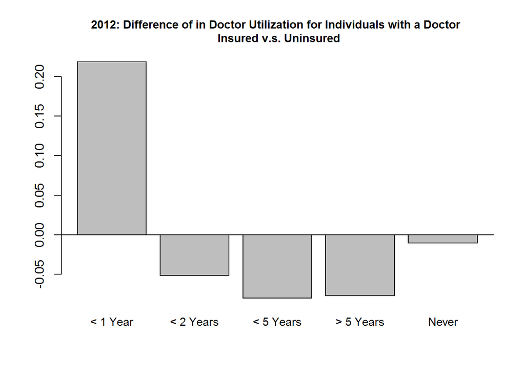

```r
barplot(CUgD.pdif.t12[2,1:5], ylim = c( min(CUgD.pdif.t12[3,1:5]) , max(CUgD.pdif.t12[1,1:5]) ),
         main = "2012: Difference of in Doctor Utilization for Individuals with a Doctor \n Insured v.s. Uninsured",
         xpd = FALSE, cex.names = .9, cex.main = 0.9 )
abline(h = 0)
```

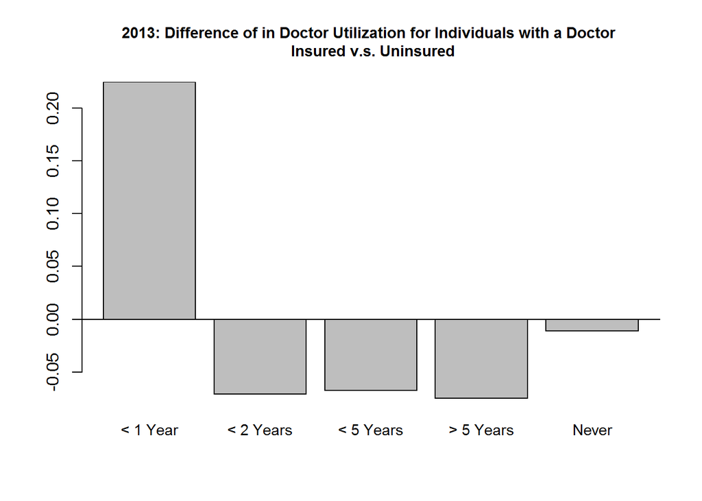

```r
barplot(CUgD.pdif.t13[2,1:5], ylim = c( min(CUgD.pdif.t13[3,1:5]) , max(CUgD.pdif.t13[1,1:5]) ),
         main = "2013: Difference of in Doctor Utilization for Individuals with a Doctor \n Insured v.s. Uninsured",
         xpd = FALSE, cex.names = .9, cex.main = 0.9 )
abline(h = 0)
```

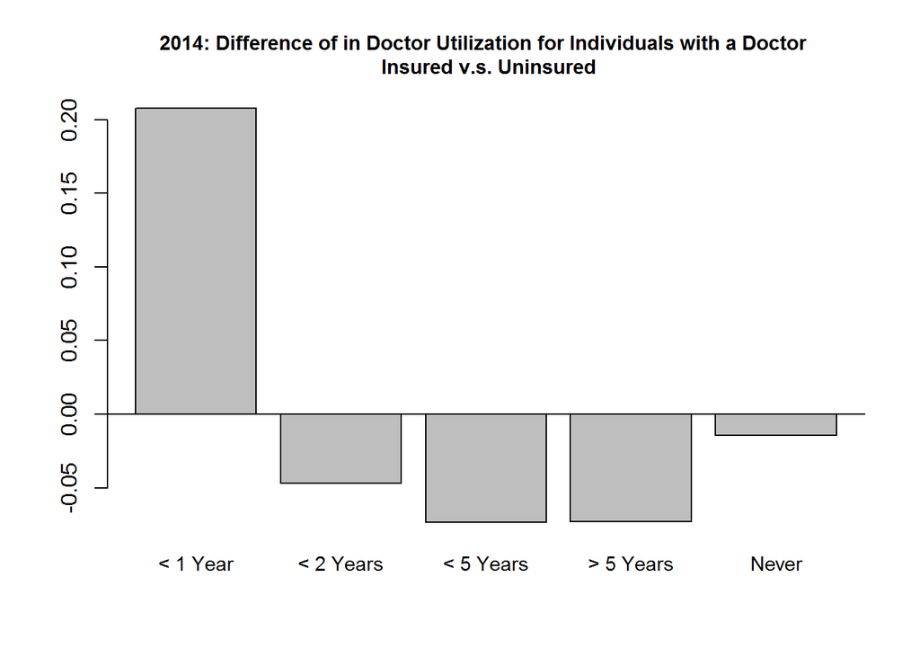

```r
barplot(CUgD.pdif.t14[2,1:5], ylim = c( min(CUgD.pdif.t14[3,1:5]) , max(CUgD.pdif.t14[1,1:5]) ),
         main = "2014: Difference of in Doctor Utilization for Individuals with a Doctor \n Insured v.s. Uninsured",
         xpd = FALSE, cex.names = .9, cex.main = 0.9 )
abline(h = 0)
```

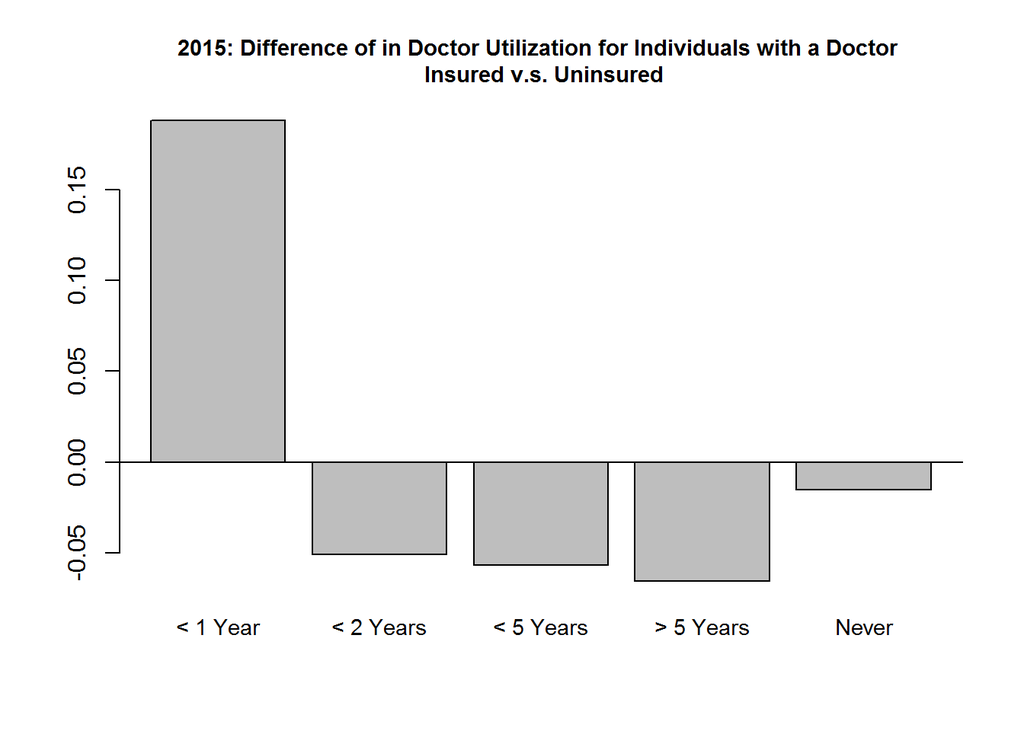

```r
barplot(CUgD.pdif.t15[2,1:5], ylim = c( min(CUgD.pdif.t15[3,1:5]) , max(CUgD.pdif.t15[1,1:5]) ),
         main = "2015: Difference of in Doctor Utilization for Individuals with a Doctor \n Insured v.s. Uninsured",
         xpd = FALSE, cex.names = .9, cex.main = 0.9 )
abline(h = 0)
```

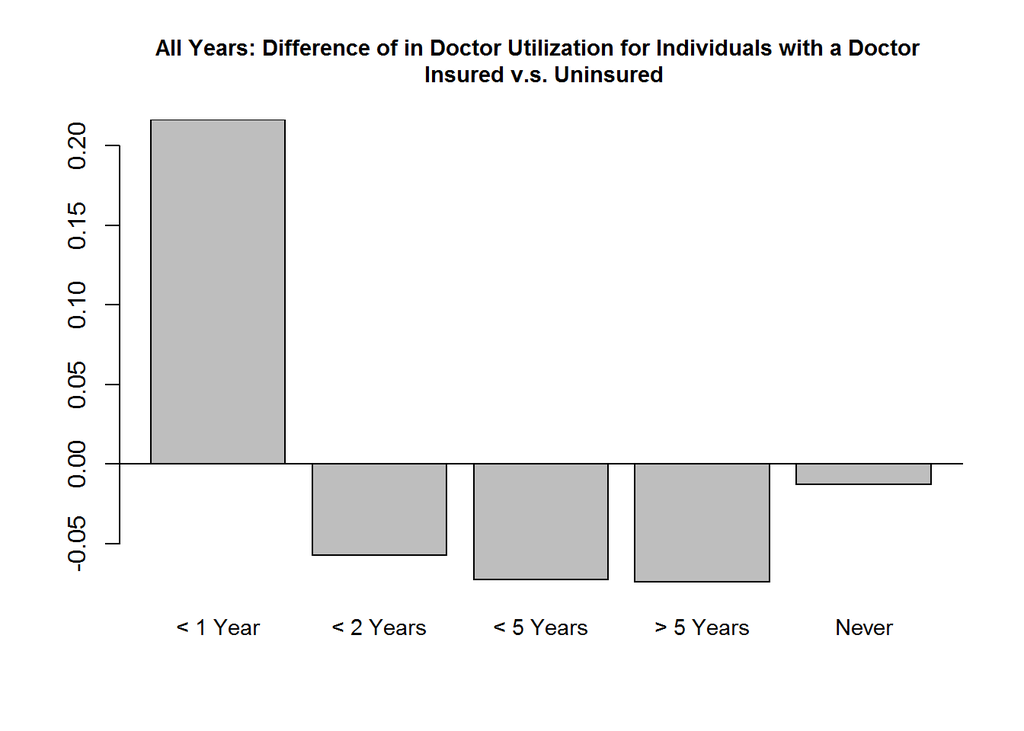

```r
barplot(CUgD.pdif.ay[2,1:5], ylim = c( min(CUgD.pdif.ay[3,1:5]) , max(CUgD.pdif.ay[1,1:5]) ),
         main = "All Years: Difference of in Doctor Utilization for Individuals with a Doctor \n Insured v.s. Uninsured",
         xpd = FALSE, cex.names = .9, cex.main = 0.9 )
abline(h = 0)
```

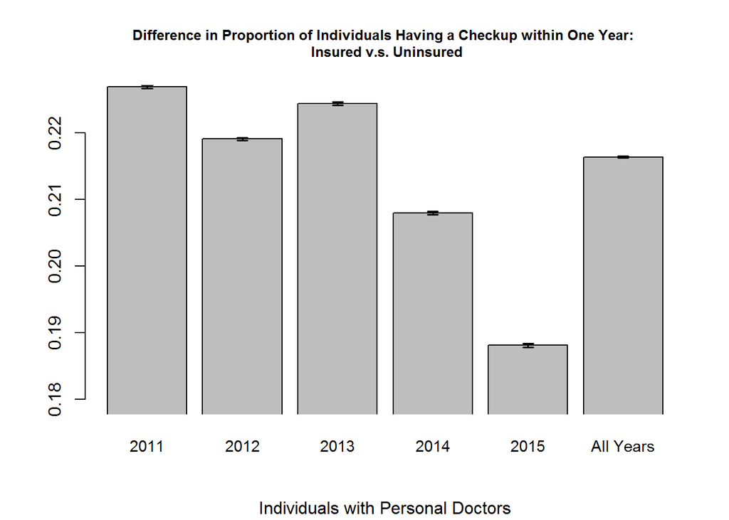

```r
CUgD.extremes.dif <- matrix(data = c(CUgD.pdif.t11[3:1,c(1, 6)], CUgD.pdif.t12[3:1,c(1, 6)], CUgD.pdif.t13[3:1,c(1, 6)],
                                   CUgD.pdif.t14[3:1,c(1, 6)], CUgD.pdif.t15[3:1,c(1, 6)], CUgD.pdif.ay[3:1,c(1, 6)]),
                          nrow = 6, ncol = 6, byrow = TRUE,
                          dimnames = list(c("2011", "2012", "2013", "2014", "2015", "All Years"),
                                          c("Lower Bound < 1", "Point Estimate < 1", "Upper Bound < 1",
                                            "Lower Bound > 5", "Point Estimate > 5", "Upper Bound > 5")))

barcenters <- barplot(CUgD.extremes.dif[,2], ylim = c( min(CUgD.extremes.dif[,1]) - 0.01 , max(CUgD.extremes.dif[,3]) ),
        main = "Difference in Proportion of Individuals Having a Checkup within One Year: \n Insured v.s. Uninsured",
        sub = "Individuals with Personal Doctors",
        xpd = FALSE, cex.names = .9, cex.main = .8 )
segments(barcenters, CUgD.extremes.dif[,1], barcenters, CUgD.extremes.dif[,3], lwd = 1.5)
arrows(barcenters, CUgD.extremes.dif[,1], barcenters, CUgD.extremes.dif[,3], lwd = 1.5, angle = 90, code = 3, length = 0.05)
```

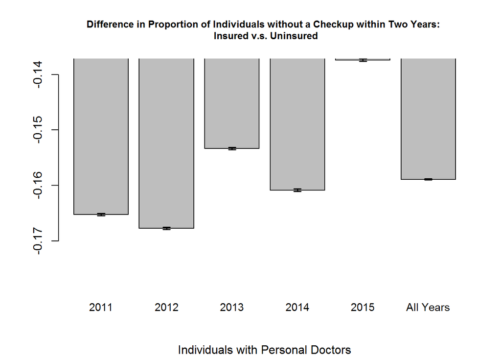

```r
barcenters <- barplot(CUgD.extremes.dif[,5], ylim = c( min(CUgD.extremes.dif[,4]) - 0.01 , max(CUgD.extremes.dif[,6]) ),
        main = "Difference in Proportion of Individuals without a Checkup within Two Years: \n Insured v.s. Uninsured",
        sub = "Individuals with Personal Doctors",
        xpd = FALSE, cex.names = .9, cex.main = .8 )
segments(barcenters, CUgD.extremes.dif[,4], barcenters, CUgD.extremes.dif[,6], lwd = 1.5)
arrows(barcenters, CUgD.extremes.dif[,4], barcenters, CUgD.extremes.dif[,6], lwd = 1.5, angle = 90, code = 3, length = 0.05)
```